[figure not shown]

# Data Intuitive fuels Tabula Sapiens v2

viash

We’re thrilled to share the exciting news of the Tabula Sapiens v2 preprint launch on bioRxiv!

Author

Data Intuitive

Published

December 6, 2024

We’re thrilled to share the exciting news of the Tabula Sapiens v2 preprint launch on bioRxiv! 🎉 Data Intuitive is proud to have played a key role in this groundbreaking project, processing massive amounts of single-cell transcriptomic data using our Viash and OpenPipelines technologies.

Check out the preprint here: https://doi.org/10.1101/2024.12.03.626516

This expanded human cell atlas now boasts data from nine new donors, doubling the number of cells and adding four new tissues. The result is an even richer resource for researchers to explore human biology at the cellular level.

The dataset will soon be available from the Tabula Sapiens Data Portal: https://tabula-sapiens.sf.czbiohub.org

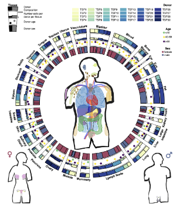

Our contribution was to tackle the immense task of processing raw 10x and Smart-Seq2 data, leveraging the power of Viash and OpenPipelines to ensure efficient and reproducible data handling. Just to give you an idea of the scale, it took the CZ Biohub HPC:

- 4520 CPU hours to process three donors’ 34TB of Smart-Seq2 raw data
- 19280 CPU hours to process donor TSP27’s 72TB of 10X raw data 🤯

Explore the Viash+Nextflow workflows we used: https://github.com/czbiohub-sf/utilities/tree/0.1.3

These workflows made use of Viash components originating from OpenPipelines: https://github.com/openpipelines-bio/openpipeline

[figure not shown]